# doc_naturalisolates

Kaitlin A. Schaal

2023-02-03

This script analyzes the data set data_naturalisolates.csv. These data are from an experiment testing the fitness relationships among three natural isolates when mixed pairwise at a 1:1 ratio before undergoing development on nutrient-free agar, and how those fitness relationships were affected when one or both strains were grown, prior to mixture/development, in a low-nutrient condition (5x lower than the standard growth condition, which is here referred to as high nutrient).

### 1: visualize the data

```r
data <- read.csv("data_naturalisolates.csv")
str(data)
```

```
## 'data.frame':    158 obs. of  11 variables:
##  $ replicate  : int  1 1 1 1 1 1 1 1 1 1 ...
##  $ plate      : chr  "D high" "D high" "D low" "D low" ...
##  $ pair       : chr  "none" "none" "none" "none" ...
##  $ trt        : chr  "none" "none" "none" "none" ...
##  $ strain     : chr  "D" "D" "D" "D" ...
##  $ nutrients  : chr  "high" "high" "low" "low" ...
##  $ strain2    : chr  "none" "none" "none" "none" ...
##  $ nutrients2 : chr  "none" "none" "none" "none" ...
##  $ antibiotics: chr  "none" "kan" "none" "kan" ...
##  $ dilution   : int  4 4 3 3 3 3 4 4 4 4 ...
##  $ cfus       : int  61 85 181 482 4 1 25 20 58 44 ...
```

```r
# remove data for replicate 1 for D:I mixes, because there was a technical issue with the selective plates
data <- data[which(!(data$replicate == 1 & data$strain == "D" & data$strain2 == "I")),]

data$plate <- as.factor(data$plate)
data$strain <- as.factor(data$strain)
data$nutrients <- as.factor(data$nutrients)
data$strain2 <- as.factor(data$strain2)
data$nutrients2 <- as.factor(data$nutrients2)
data$antibiotics <- as.factor(data$antibiotics)

# rearrange the order of strains
data$strain <- factor(data$strain, levels = c("D", "DK801", "I", "G", "Mxx41"))
data$pair <- factor(data$pair, levels = c("none", "D:I", "D:G", "I:G"))

# for counts of zero CFUs, calculate the maximum undetectable number of CFUs.
for (i in 1:nrow(data)) {
  if (data$cfus[i] == 0) data$cfus[i] <- 0.9
}

# calculate the total number of spores
data <- mutate(data, numspores = cfus * 10^dilution)
data <- mutate(data, logspores = log10(numspores + 1))
str(data)
```

```
## 'data.frame':    150 obs. of  13 variables:
##  $ replicate  : int  1 1 1 1 1 1 1 1 1 1 ...
##  $ plate      : Factor w/ 21 levels "D high","D high:G high",..: 1 1 6 6 11 12 13 13 16 16 ...
##  $ pair       : Factor w/ 4 levels "none","D:I","D:G",..: 1 1 1 1 1 1 1 1 1 1 ...
##  $ trt        : chr  "none" "none" "none" "none" ...
##  $ strain     : Factor w/ 5 levels "D","DK801","I",..: 1 1 1 1 2 2 4 4 4 4 ...
##  $ nutrients  : Factor w/ 2 levels "high","low": 1 1 2 2 1 2 1 1 2 2 ...
##  $ strain2    : Factor w/ 3 levels "G","I","none": 3 3 3 3 3 3 3 3 3 3 ...
##  $ nutrients2 : Factor w/ 3 levels "high","low","none": 3 3 3 3 3 3 3 3 3 3 ...
##  $ antibiotics: Factor w/ 3 levels "kan","none","novo": 2 1 2 1 2 2 3 2 3 2 ...
##  $ dilution   : int  4 4 3 3 3 3 4 4 4 4 ...
##  $ cfus       : num  61 85 181 482 4 1 25 20 58 44 ...
##  $ numspores  : num  610000 850000 181000 482000 4000 1000 250000 200000 580000 440000 ...
##  $ logspores  : num  5.79 5.93 5.26 5.68 3.6 ...
```

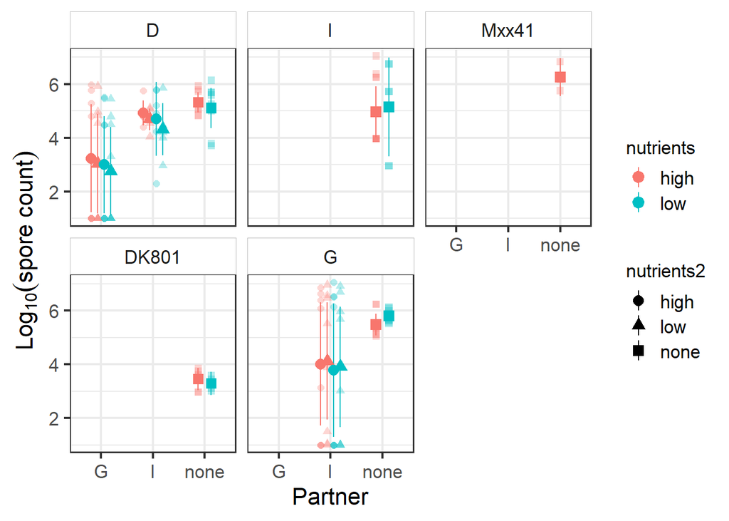

```r
pdata <- ggplot(data, aes(x = strain2, y = logspores, color = nutrients, shape = nutrients2)) +
  geom_point(size = 2, alpha = 0.3, show.legend = FALSE, position = position_dodge(width = 0.5)) +
  stat_summary(fun.data = "mean_cl_normal", size = 0.7, aes(y = logspores), position = position_dodge(width = 0.5)) +
  facet_wrap(~strain, dir = "v", ncol = 3) +
  labs(y = expression(Log[10]("spore count")), x = "Partner") +
  customPlotTheme
pdata
```

#### 1.1: checking marker effects

Clonal cultures of each strain were germinated in media with or without antibiotic as a control for the effect of the antibiotic on viable spore counts. As expected, GJV1 did not produce spores in the presence of the antibiotic, as can be seen by the 0 counts in the initial data table. We look at the effect of antibiotics on the cheater strains.

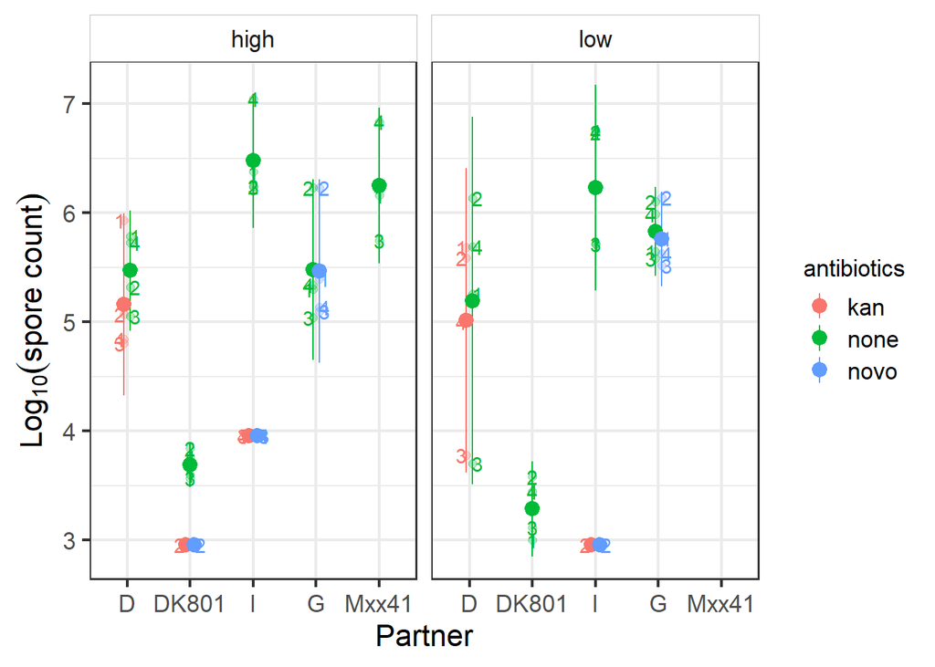

```r
# select the data for the cheaters in pure culture and remove levels from the parent data set that are no longer present
dataTest <- data[which(data$strain2 == "none"),]
dataTest <- droplevels(dataTest)

pmarker <- ggplot(dataTest, aes(x = strain, y = logspores, color = antibiotics, label = replicate)) +
  geom_point(size = 2, alpha = 0.3, show.legend = FALSE, position = position_dodge(width = 0.2)) +
  stat_summary(fun.data = "mean_cl_normal", size = 0.7, aes(y = logspores), position = position_dodge(width = 0.2)) +
  facet_wrap(~nutrients, dir = "v", ncol = 2) +
  geom_text(position = position_dodge(width = 0.5), show.legend = FALSE) +
  labs(y = expression(Log[10]("spore count")), x = "Partner") +
  customPlotTheme
pmarker
```

D may sporulate better than its ancestor. G’s ancestor was only assayed at high nutrients and no antibiotics. D’s ancestor and I carry no resistance markers, and are seen to produce no spores when germinated in the presence of antibiotic.

Only D and G need be tested for the effect of antibiotic on CFU counts. We check for evidence of no effect by looking at the confidence intervals for the difference in means.

```r
dataTest <- dataTest[which(dataTest$strain == "D" | dataTest$strain == "G"),]
dataTest <- droplevels(dataTest)

# initialize a data frame to store the resulting confidence intervals for each test
cis <- data.frame(strains = levels(dataTest$plate), mean = 1, lower = 1, upper = 1)

# for each strain under low or high nutrients, test the difference in means with vs without antibiotic, paired by replicate
for (i in 1:length(levels(dataTest$plate))) {
  x = dataTest[which(dataTest$plate == levels(dataTest$plate)[i] & dataTest$antibiotics == "none"), "logspores"]
  y = dataTest[which(dataTest$plate == levels(dataTest$plate)[i] & dataTest$antibiotics != "none"), "logspores"]
  result <- MeanDiffCI(x, y, method = "classic", conf.level = 0.95, sides = "two.sided", paired = TRUE)
  cis[i,2] <- result[1]
  cis[i,3] <- result[2]
  cis[i,4] <- result[3]
}
cis
```

```
##   strains       mean      lower     upper
## 1  D high 0.30860192 -0.3698352 0.9870391
## 2   D low 0.18287151 -0.6529522 1.0186953
## 3  G high 0.01361939 -0.2009321 0.2281709
## 4   G low 0.06744052 -0.2725038 0.4073849
```

There is at most less than half a log of difference in CFU counts in the presence of antibiotic for G. For D, the difference could be up to a log. Overall, the average differences are considered reasonably low, and we proceed.

### 2: pure culture spoulation in different nutrient conditions

```r
dataPC <- data[which(data$strain2 == "none" & data$strain != "DK801"),]
dataPC <- dataPC[which(!(dataPC$strain == "I" & dataPC$antibiotics != "none")),]
dataPC <- dataPC[which(!(dataPC$strain != "I" & dataPC$antibiotics == "none")),]
dataPC <- droplevels(dataPC)
```

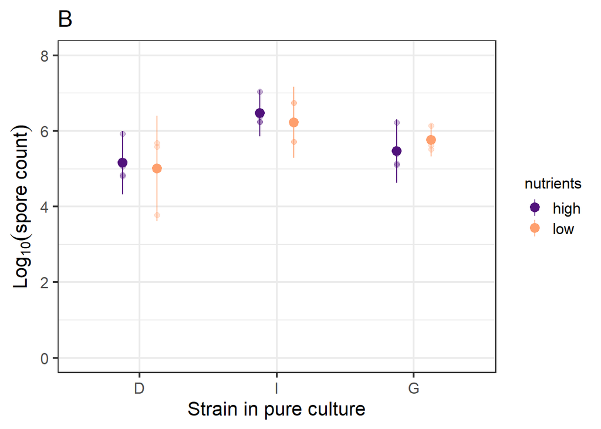

```r
pPC2 <- ggplot(dataPC, aes(x = strain, y = logspores, color = nutrients)) +
  geom_point(size = 2, alpha = 0.3, show.legend = FALSE, position = position_dodge(width = 0.5)) +
  stat_summary(fun.data = "mean_cl_normal", size = 0.7, aes(y = logspores), position = position_dodge(width = 0.5)) +
  coord_cartesian(ylim = c(0,8)) +
  labs(y = expression(Log[10]("spore count")), x = "Strain in pure culture", title = "B") +
  customPlotTheme +
  scale_color_viridis_d(option = "magma", begin = 0.25, end = 0.8, direction = 1)
pPC2
```

#### 2.1: statistics

For each strain, is there a difference in pure culture sporulation based on nutrient condition? We run an ANOVA

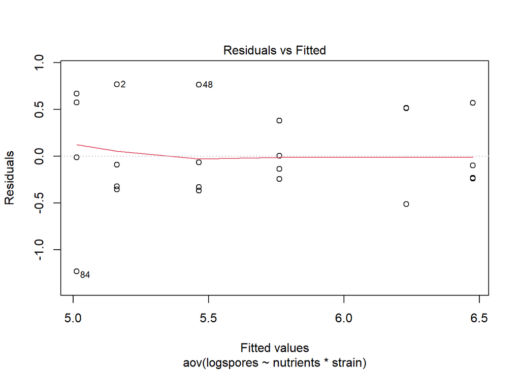

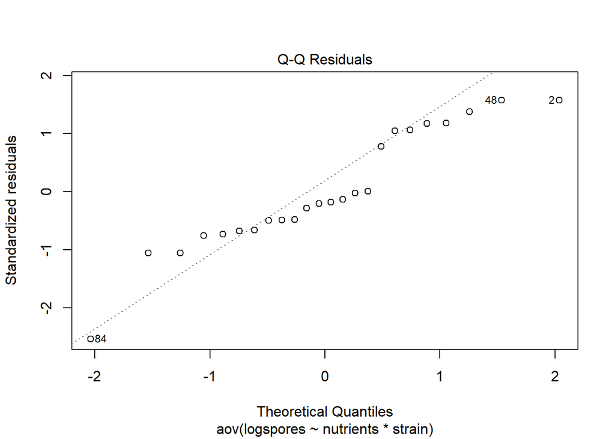

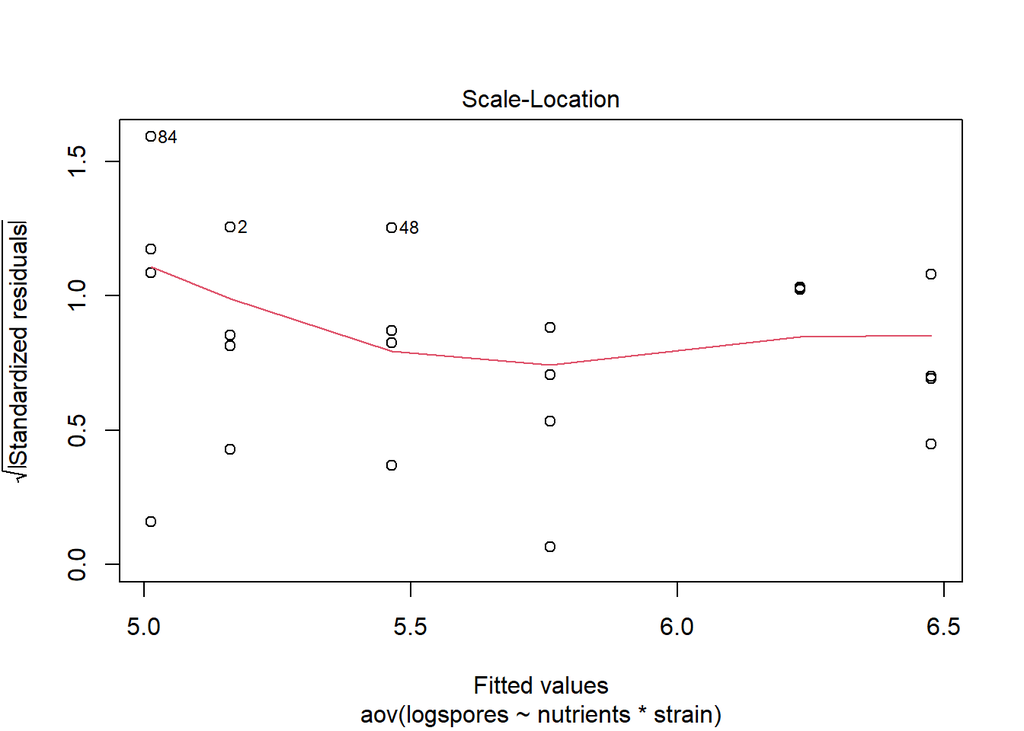

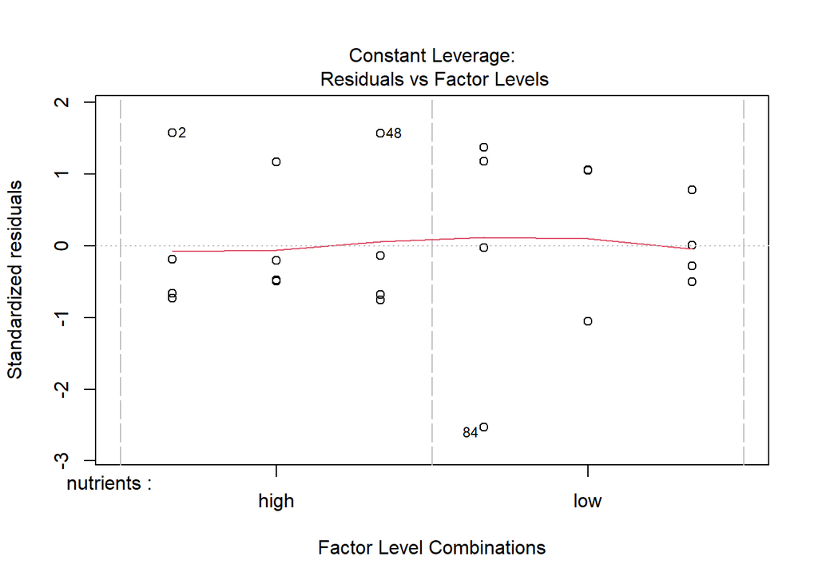

```r
fit <- aov(logspores ~ nutrients * strain, data = dataPC)
plot(fit)
```

```r
summary(fit)
```

```
##                  Df Sum Sq Mean Sq F value  Pr(>F)
## nutrients         1  0.007   0.007   0.021 0.88747
## strain            2  6.475   3.237  10.239 0.00107 **
## nutrients:strain  2  0.335   0.168   0.530 0.59758
## Residuals        18  5.691   0.316
## ---
## Signif. codes:  0 '***' 0.001 '**' 0.01 '*' 0.05 '.' 0.1 ' ' 1
```

The qqplot looks ok. We proceed under the assumption of normality. There is a significant effect of strain (strains produce different numbers of spores), but there is no evidence of an interaction effect or of an effect of nutrient condition on its own. We run a new model with strain alone and use post-hoc Tukey tests to see the differences among the strains.

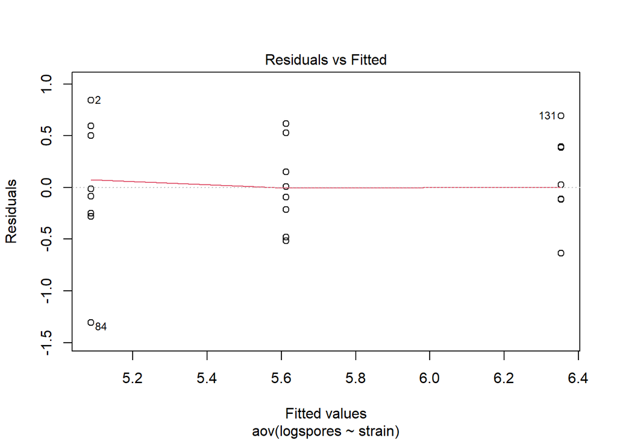

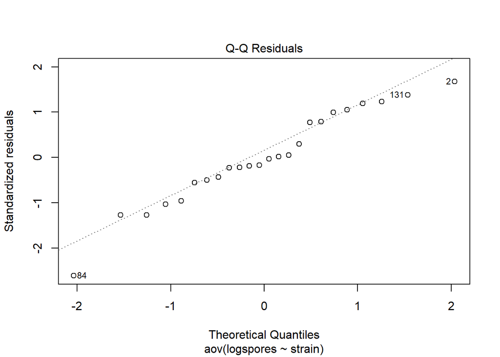

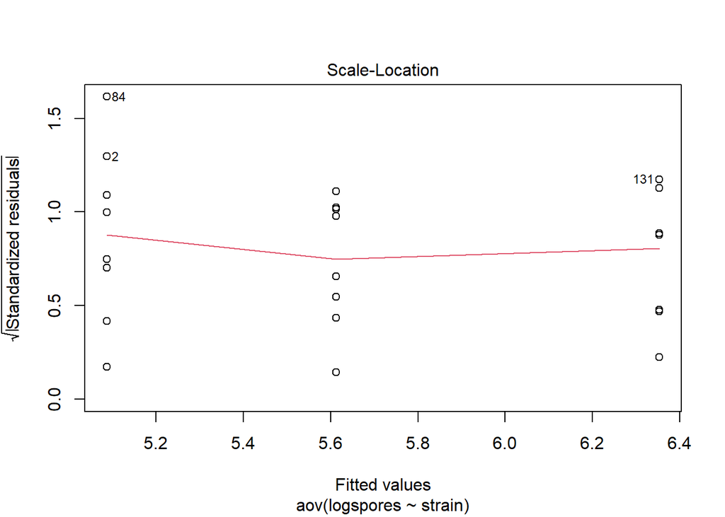

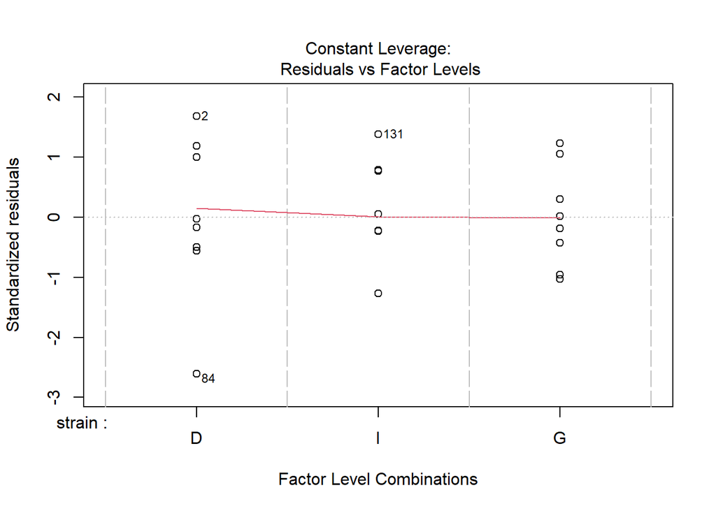

```r
fit <- aov(logspores ~ strain, data = dataPC)
plot(fit)
```

```r
summary(fit)
```

```
##             Df Sum Sq Mean Sq F value   Pr(>F)
## strain       2  6.475   3.237   11.27 0.000473 ***
## Residuals   21  6.033   0.287
## ---
## Signif. codes:  0 '***' 0.001 '**' 0.01 '*' 0.05 '.' 0.1 ' ' 1
```

```r
TukeyHSD(fit)
```

```
##   Tukey multiple comparisons of means
##     95% family-wise confidence level
##
## Fit: aov(formula = logspores ~ strain, data = dataPC)
##
## $strain
##           diff        lwr         upr     p adj
## I-D  1.2662537  0.5907656  1.94174185 0.0003256
## G-D  0.5260731 -0.1494150  1.20156126 0.1462692
## G-I -0.7401806 -1.4156687 -0.06469246 0.0301317
```

Strain G is estimated to produce more spores than D, but this is not significant and therefore cannot be assumed to be true. However, strain I produces more spores than both G (p = 0.03) and D (p = 0.0003).

### 3: calculate the mixing effect

We first calculate the sporulation of each strain in mixture.

```r
data2 <- data[which(data$strain != "DK801" & data$strain != "Mxx41"),]
data2 <- data2[which(!(data2$antibiotics == "none" & data2$strain2 == "none" & data2$strain != "I")),]
data2 <- data2[which(!(data2$strain == "I" & data2$antibiotics != "none")),]

data2 <- mutate(data2, count = 1)
for (i in 1:nrow(data2)) {
  if (data2$antibiotics[i] == "kan") data2$count[i] <- "D"
  if (data2$antibiotics[i] == "novo") data2$count[i] <- "G"
  if (data2$antibiotics[i] == "none") data2$count[i] <- "total"
  if (data2$antibiotics[i] == "none" & data2$strain[i] == "I") data2$count[i] <- "I"
}
data2 <- pivot_wider(data2, id_cols = -c("dilution", "cfus", "logspores"), names_from = "count", values_from = "numspores")

for (i in 1:nrow(data2)) {
  if (!(is.na(data2$total[i])) & data2$strain[i] == "D") data2$I[i] <- data2$total[i] - data2$D[data2$replicate == data2$replicate[i] & data2$plate == data2$plate[i] & data2$antibiotics == "kan"]
  if (!(is.na(data2$total[i])) & data2$strain[i] == "G") data2$I[i] <- data2$total[i] - data2$G[data2$replicate == data2$replicate[i] & data2$plate == data2$plate[i] & data2$antibiotics == "novo"]
  if (!(is.na(data2$G[i])) & data2$strain2[i] == "G") data2$total[i] <- data2$G[i] + data2$D[data2$replicate == data2$replicate[i] & data2$plate == data2$plate[i] & data2$antibiotics == "kan"]
}

data2 <- pivot_longer(data2, cols = 10:13, names_to = "count", values_to = "numspores", values_drop_na = T)

data2$count <- as.factor(data2$count)
data2$count <- factor(data2$count, levels = c("D", "I", "G", "total"))

# drop the antibiotics column because it no longer makes sense
data2 <- subset(data2, select = -c(antibiotics))
```

```r
#calculate the total number of spores
data2 <- mutate(data2, logspores = log10(numspores + 1))
```

Calculate the mixing effect

Ci(j) = log10(final spores of strain i in mixture with j/initial cells of strain i in mixture with j) - log10(final spores of strain i in pure culture/initial cells of strain i in pure culture)

This is equivalent to

Ci(j) = log10((number of cells in PC/number of cells of i in the initial mixture with j) * (number of spores of i produced in mixture with j/number of spores i produced in PC))

We know from the protocol that the same total number of cells was used to initiate development, and that in mixes, strains were combined 1:1. In this case, we get

Ci(j) = log10(2 * (number of spores of i produced in mixture with j/number of spores i produced in PC))

```r
# take only the data for mixes
datamix <- data2[which(data2$strain2 != "none" & data2$count != "total"),]
datamix <- droplevels(datamix) # drop unused levels inherited from the parent data set

# we already have the corresponding pure culture data
# initialize the Ci(j) column
datamix <- mutate(datamix, cij = 17)

# for each strain in each mixture, calculate the Ci(j)
for (i in 1:nrow(datamix)) {
  # relevant nutrient condition for this Ci(j)
  if (datamix$count[i] == datamix$strain[i]) relnut <- datamix$nutrients[i]
  if (datamix$count[i] == datamix$strain2[i]) relnut <- datamix$nutrients2[i]

  if (datamix$numspores[i] < 1) datamix$numspores[i] <- 1

  datamix$cij[i] <- log10(2 * datamix$numspores[i]/dataPC[which(dataPC$replicate == datamix$replicate[i] & dataPC$strain == datamix$count[i] & dataPC$nutrients == relnut),"numspores"])
}
```

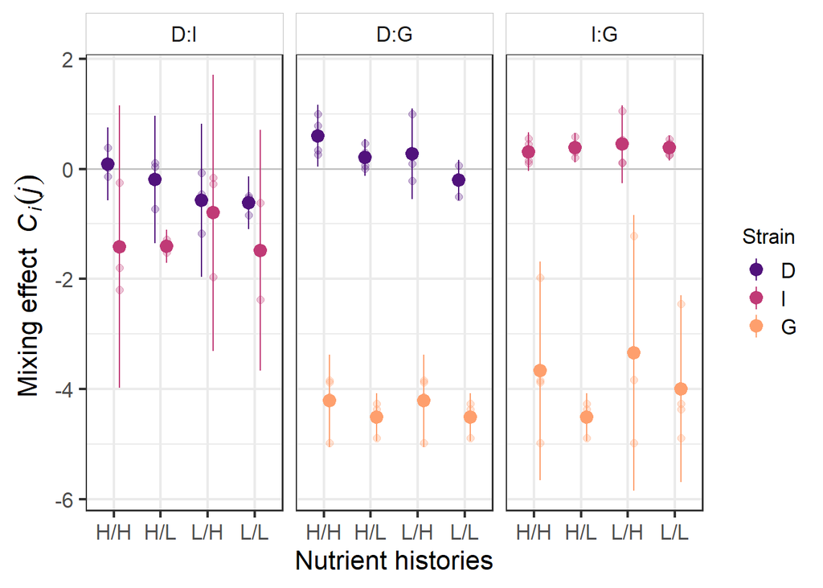

```r
pcij <- ggplot(datamix, aes(x = trt, y = cij, color = count)) +
  geom_abline(slope = 0, intercept = 0, color = "grey") +
  geom_point(size = 2, alpha = 0.3, show.legend = FALSE, position = position_dodge(width = 0.5)) +
  stat_summary(fun.data = "mean_cl_normal", size = 0.7, aes(y = cij), position = position_dodge(width = 0.5)) +
  customPlotTheme +
  scale_color_viridis_d(option = "magma", begin = 0.25, end = 0.8, direction = 1) +
  facet_wrap(~pair, dir = "v", ncol = 3) +
  labs(y = "Mixing effect "~italic(C[i](j))~"", x = "Nutrient histories", color = "Strain")
pcij
```

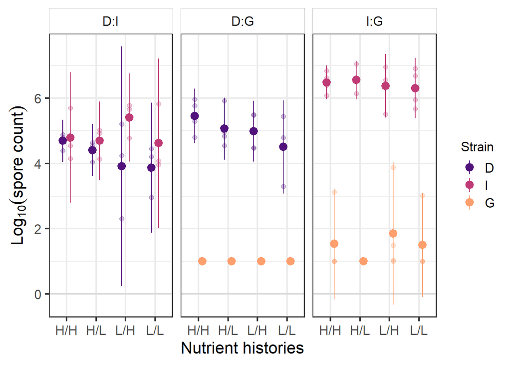

```r
pspores <- ggplot(datamix, aes(x = trt, y = logspores, color = count)) +
  geom_abline(slope = 0, intercept = 0, color = "grey") +
  geom_point(size = 2, alpha = 0.3, show.legend = FALSE, position = position_dodge(width = 0.5)) +
  stat_summary(fun.data = "mean_cl_normal", size = 0.7, aes(y = logspores), position = position_dodge(width = 0.5)) +
  customPlotTheme +
  scale_color_viridis_d(option = "magma", begin = 0.25, end = 0.8, direction = 1) +
  facet_wrap(~pair, dir = "v", ncol = 3) +
  labs(y = expression(Log[10]("spore count")), x = "Nutrient histories", color = "Strain")
pspores
```

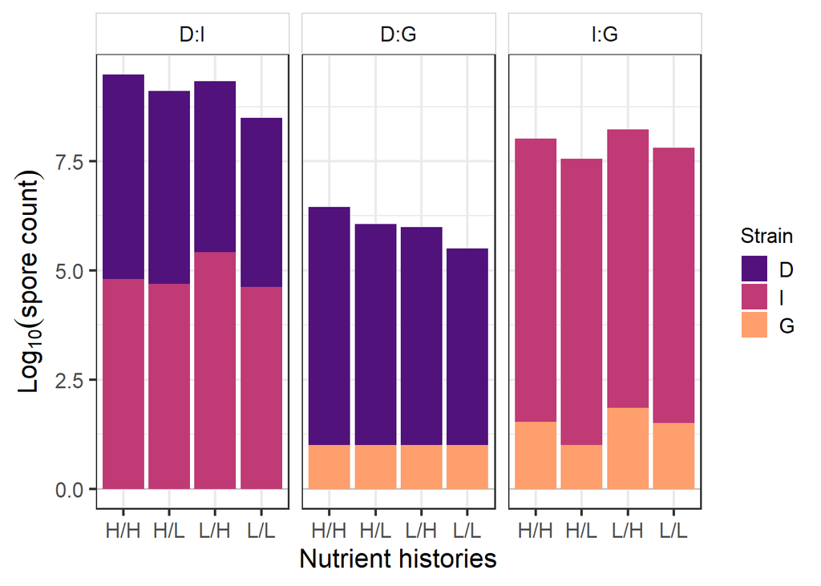

```r
bar <- summarySE(data = datamix, measurevar = "logspores", groupvars = c("count", "trt", "pair"))

pspores2 <- ggplot(bar, aes(x = trt, y = logspores, fill = count)) +
  geom_abline(slope = 0, intercept = 0, color = "grey") +
  geom_bar(aes(y = logspores), stat = "identity", position = "stack") +
  #geom_point(aes(fill = count), color = "black", size = 2, show.legend = FALSE, position = "jitter") +
  customPlotTheme +
  scale_fill_viridis_d(option = "magma", begin = 0.25, end = 0.8, direction = 1) +
  facet_wrap(~pair, dir = "v", ncol = 3) +
  labs(y = expression(Log[10]("spore count")), x = "Nutrient histories", fill = "Strain")
pspores2
```

#### 3.1: statistics

We would like to know if prior nutrient condition of the strains affects their performance in mixture. We first test the competitive hierarchy of the strains by focusing on the high/high nutrient condition and looking at whether the Ci(j)s are different from zero (i.e. did being in mixture affect the performance of the strain).

Specifically, we are interested in exploitation. We say that strain i exploits j when Ci(j) is greater than zero.

We first test for the transitive exploitation hierarchy which has been previously observed: D exploits I and G, and I exploits G (under H/H, which are the standard lab conditions). We use individual one-tailed t-tests.

```r
c("D exploits I")
```

```
## [1] "D exploits I"
```

```r
t.test(datamix[which(datamix$plate == "D high:I high" & datamix$count == "D"), "cij"], alternative = "greater", mu = 0)
```

```
##
##  One Sample t-test
##
## data:  datamix[which(datamix$plate == "D high:I high" & datamix$count == "D"), "cij"]
## t = 0.56907, df = 2, p-value = 0.3133
## alternative hypothesis: true mean is greater than 0
## 95 percent confidence interval:
##  -0.362166       Inf
## sample estimates:
##  mean of x
## 0.08766711
```

```r
c("D exploits G")
```

```
## [1] "D exploits G"
```

```r
t.test(x = datamix[which(datamix$plate == "D high:G high" & datamix$count == "D"), "cij"], alternative = "greater", mu = 0)
```

```
##
##  One Sample t-test
##
## data:  datamix[which(datamix$plate == "D high:G high" & datamix$count == "D"), "cij"]
## t = 3.3872, df = 3, p-value = 0.02143
## alternative hypothesis: true mean is greater than 0
## 95 percent confidence interval:
##  0.1822875       Inf
## sample estimates:
## mean of x
##  0.597228
```

```r
c("I exploits G")
```

```
## [1] "I exploits G"
```

```r
t.test(x = datamix[which(datamix$plate == "G high:I high" & datamix$count == "I"), "cij"], alternative = "greater", mu = 0)
```

```
##
##  One Sample t-test
##
## data:  datamix[which(datamix$plate == "G high:I high" & datamix$count == "I"), "cij"]
## t = 2.8147, df = 3, p-value = 0.03352
## alternative hypothesis: true mean is greater than 0
## 95 percent confidence interval:
##  0.05107615        Inf
## sample estimates:
## mean of x
## 0.3116258
```

Now we test for exploitation across all nutritional history treatments for each pair.

##### 3.1.1: D:I

ANOVA for effect of nutritional history on the two competitors.

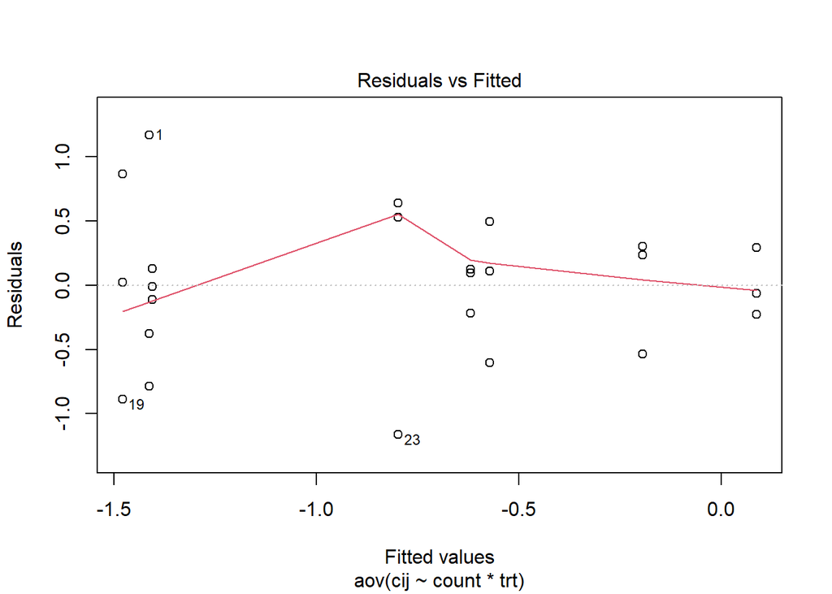

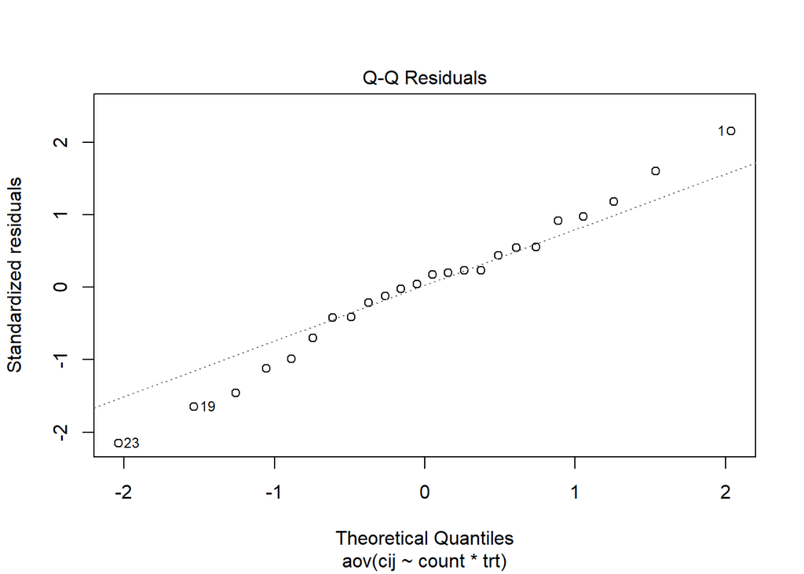

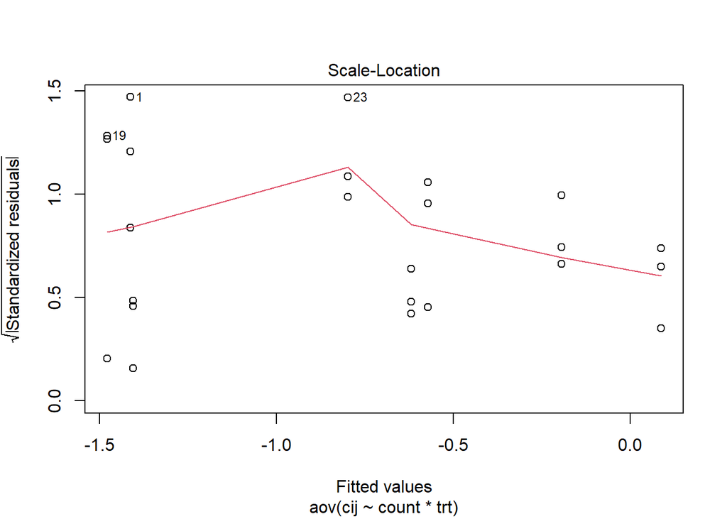

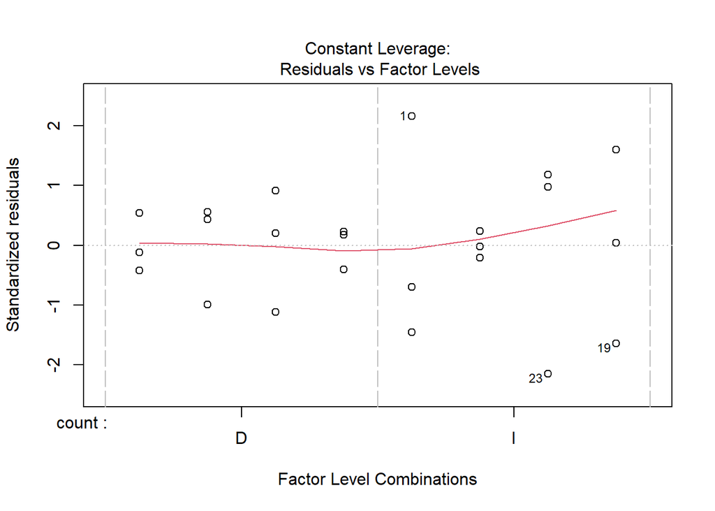

```r
fit <- aov(cij ~ count * trt, data = datamix[which(datamix$pair == "D:I"),])
plot(fit)
```

```r
summary(fit)
```

```
##             Df Sum Sq Mean Sq F value  Pr(>F)
## count        1  5.404   5.404  12.339 0.00289 **
## trt          3  0.566   0.189   0.431 0.73388
## count:trt    3  1.354   0.451   1.031 0.40546
## Residuals   16  7.007   0.438
## ---
## Signif. codes:  0 '***' 0.001 '**' 0.01 '*' 0.05 '.' 0.1 ' ' 1
```

t-tests for Ci(j)s different from zero:

```r
dataT <- datamix[which(datamix$pair == "D:I" & datamix$trt != "H/H"),]
dataT <- droplevels(dataT)

# initialize a data frame to store the resulting p-value, mean, and 95% CI for each test
ttests <- data.frame(plate = levels(dataT$plate), strain = levels(dataT$strain)[1], pval = 1, tstat = 1, df = 1, stdev = 1, mean = 1, CIlower = 1, CIupper = 1)
ttests2 <- data.frame(plate = levels(dataT$plate), strain = levels(dataT$strain2)[1], pval = 1, tstat = 1, df = 1, stdev = 1, mean = 1, CIlower = 1, CIupper = 1)
ttests <- dplyr::bind_rows(ttests, ttests2)

# initialize a vector to store the p-values from each test so that they can be corrected for multiple testing
pvalues <- c()

# run the iterated tests
for (i in 1:nrow(ttests)) {
  n = 4 # the number of samples
  dataTest <- subset(dataT, plate == ttests$plate[i] & count == ttests$strain[i])
  res <- t.test(dataTest$cij, alternative = "two.sided", mu = 0)
  pvalues <- c(pvalues, res$p.value)
  ttests[i,4] <- res$statistic
  ttests[i,5] <- res$parameter
  ttests[i,6] <- res$stderr * n^2
  ttests[i,7] <- as.numeric(res$estimate[1])
  ttests[i,8] <- as.numeric(res$conf.int[1])
  ttests[i,9] <- as.numeric(res$conf.int[2])
}

# do the multiple testing correction
pCorr <- round(p.adjust(pvalues, method = "BH"), 4)

# enter the corrected p-values into the data frame
for (i in 1:nrow(ttests)) {
  ttests[i,3] <- pCorr[i]
}
ttests
```

```
##          plate strain   pval       tstat df    stdev       mean   CIlower
## 1 D high:I low      D 0.5455  -0.7215953  2 4.295675 -0.1937337 -1.348908
## 2 D low:I high      D 0.3270  -1.7744864  2 5.152082 -0.5713937 -1.956870
## 3  D low:I low      D 0.0913  -5.6017528  2 1.768258 -0.6190839 -1.094596
## 4 D high:I low      I 0.0146 -20.2235591  2 1.111347 -1.4047118 -1.703570
## 5 D low:I high      I 0.3657  -1.3680002  2 9.325052 -0.7972920 -3.304946
## 6  D low:I low      I 0.2004  -2.9161631  2 8.112710 -1.4786241 -3.660260
##      CIupper
## 1  0.9614411
## 2  0.8140825
## 3 -0.1435715
## 4 -1.1058530
## 5  1.7103616
## 6  0.7030117
```

Dunnett tests for difference in other nutritional history treatments from H/H treatment (standard lab conditions):

```r
dataT <- datamix[which(datamix$pair == "D:I"),]
dataT <- droplevels(dataT)

c("D")
```

```
## [1] "D"
```

```r
DunnettTest(cij ~ trt, data = dataT[which(dataT$count == "D"),], control = "H/H")
```

```
##
##   Dunnett's test for comparing several treatments with a control :
##     95% family-wise confidence level
##
## $`H/H`
##               diff    lwr.ci    upr.ci   pval
## H/L-H/H -0.2814008 -1.218839 0.6560372 0.7284
## L/H-H/H -0.6590608 -1.596499 0.2783772 0.1764
## L/L-H/H -0.7067510 -1.644189 0.2306870 0.1430
##
## ---
## Signif. codes:  0 '***' 0.001 '**' 0.01 '*' 0.05 '.' 0.1 ' ' 1
```

```r
c("I")
```

```
## [1] "I"
```

```r
DunnettTest(cij ~ trt, data = dataT[which(dataT$count == "I"),], control = "H/H")
```

```
##
##   Dunnett's test for comparing several treatments with a control :
##     95% family-wise confidence level
##
## $`H/H`
##                 diff    lwr.ci   upr.ci   pval
## H/L-H/H  0.007252147 -1.984920 1.999424 1.0000
## L/H-H/H  0.614671861 -1.377500 2.606844 0.7135
## L/L-H/H -0.066660147 -2.058832 1.925512 0.9993
##
## ---
## Signif. codes:  0 '***' 0.001 '**' 0.01 '*' 0.05 '.' 0.1 ' ' 1
```

##### 3.1.2: D:G

ANOVA for effect of nutritional history on the two competitors.

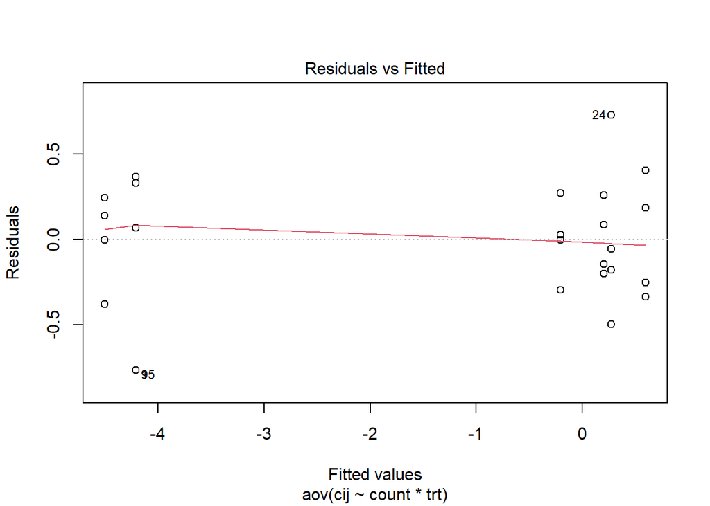

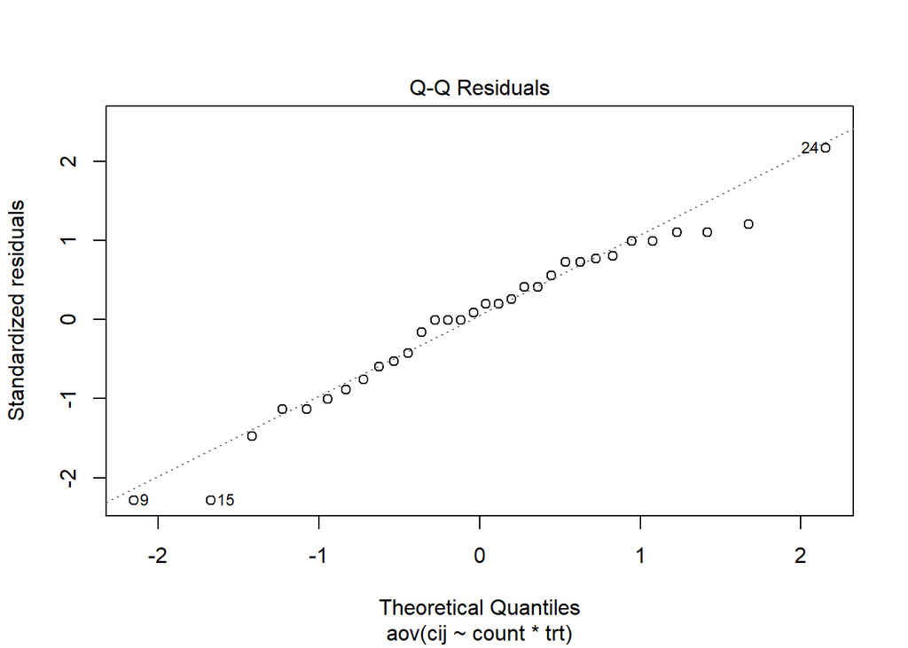

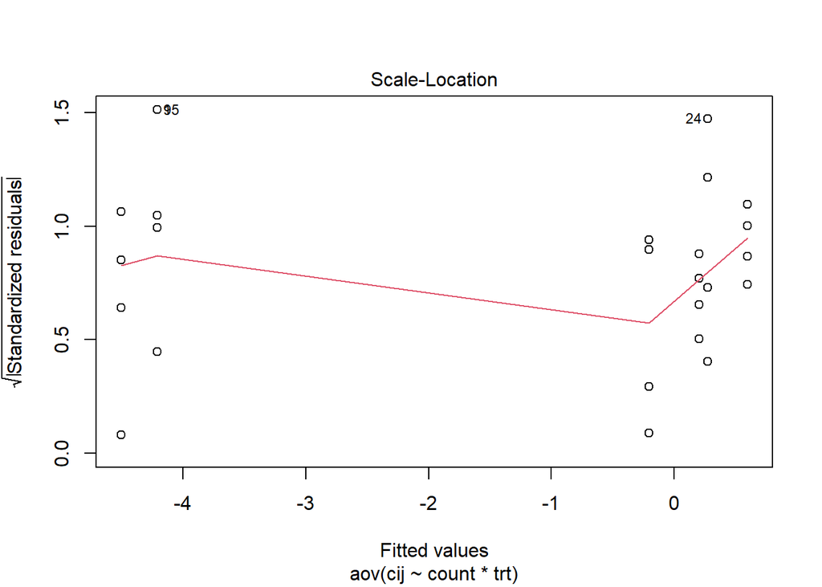

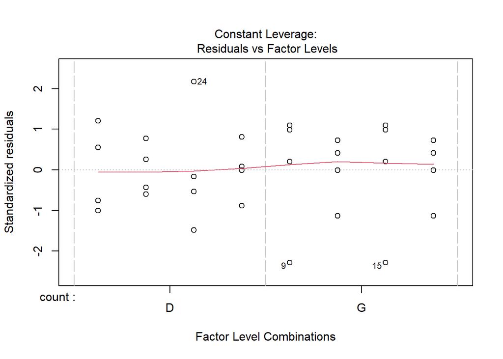

```r
fit <- aov(cij ~ count * trt, data = datamix[which(datamix$pair == "D:G"),])
plot(fit)
```

```r
summary(fit)
```

```
##             Df Sum Sq Mean Sq  F value Pr(>F)
## count        1 167.47  167.47 1119.272 <2e-16 ***
## trt          3   1.34    0.45    2.993 0.0508 .
## count:trt    3   0.31    0.10    0.695 0.5643
## Residuals   24   3.59    0.15
## ---
## Signif. codes:  0 '***' 0.001 '**' 0.01 '*' 0.05 '.' 0.1 ' ' 1
```

t-tests for Ci(j)s different from zero:

```r
dataT <- datamix[which(datamix$pair == "D:G" & datamix$trt != "H/H"),]
dataT <- droplevels(dataT)

# initialize a data frame to store the resulting p-value, mean, and 95% CI for each test
ttests <- data.frame(plate = levels(dataT$plate), strain = levels(dataT$strain)[1], pval = 1, tstat = 1, df = 1, stdev = 1, mean = 1, CIlower = 1, CIupper = 1)
ttests2 <- data.frame(plate = levels(dataT$plate), strain = levels(dataT$strain2)[1], pval = 1, tstat = 1, df = 1, stdev = 1, mean = 1, CIlower = 1, CIupper = 1)
ttests <- dplyr::bind_rows(ttests, ttests2)

# initialize a vector to store the p-values from each test so that they can be corrected for multiple testing
pvalues <- c()

# run the iterated tests
for (i in 1:nrow(ttests)) {
  n = 4 # the number of samples
  dataTest <- subset(dataT, plate == ttests$plate[i] & count == ttests$strain[i])
  res <- t.test(dataTest$cij, alternative = "two.sided", mu = 0)
  pvalues <- c(pvalues, res$p.value)
  ttests[i,4] <- res$statistic
  ttests[i,5] <- res$parameter
  ttests[i,6] <- res$stderr * n^2
  ttests[i,7] <- as.numeric(res$estimate[1])
  ttests[i,8] <- as.numeric(res$conf.int[1])
  ttests[i,9] <- as.numeric(res$conf.int[2])
}

# do the multiple testing correction
pCorr <- round(p.adjust(pvalues, method = "BH"), 4)

# enter the corrected p-values into the data frame
for (i in 1:nrow(ttests)) {
  ttests[i,3] <- pCorr[i]
}
ttests
```

```
##          plate strain   pval      tstat df    stdev       mean    CIlower
## 1 D high:G low      D 0.2107   1.943598  3 1.691559  0.2054820 -0.1309740
## 2 D low:G high      D 0.3701   1.051796  3 4.151850  0.2729311 -0.5528840
## 3  D low:G low      D 0.2107  -1.766114  3 1.856981 -0.2049774 -0.5743362
## 4 D high:G low      G 0.0002 -33.178861  3 2.172947 -4.5059951 -4.9382006
## 5 D low:G high      G 0.0011 -15.950431  3 4.222519 -4.2094370 -5.0493081
## 6  D low:G low      G 0.0002 -33.178861  3 2.172947 -4.5059951 -4.9382006
##      CIupper
## 1  0.5419380
## 2  1.0987462
## 3  0.1643814
## 4 -4.0737895
## 5 -3.3695658
## 6 -4.0737895
```

Dunnett tests for difference in other nutritional history treatments from H/H treatment (standard lab conditions):

```r
dataT <- datamix[which(datamix$pair == "D:G"),]
dataT <- droplevels(dataT)

c("D")
```

```
## [1] "D"
```

```r
DunnettTest(cij ~ trt, data = dataT[which(dataT$count == "D"),], control = "H/H")
```

```
##
##   Dunnett's test for comparing several treatments with a control :
##     95% family-wise confidence level
##
## $`H/H`
##               diff     lwr.ci     upr.ci   pval
## H/L-H/H -0.3917460 -1.0573866  0.2738946 0.3088
## L/H-H/H -0.3242969 -0.9899375  0.3413437 0.4472
## L/L-H/H -0.8022055 -1.4678461 -0.1365649 0.0184 *
##
## ---
## Signif. codes:  0 '***' 0.001 '**' 0.01 '*' 0.05 '.' 0.1 ' ' 1
```

```r
c("G")
```

```
## [1] "G"
```

```r
DunnettTest(cij ~ trt, data = dataT[which(dataT$count == "G"),], control = "H/H")
```

```
##
##   Dunnett's test for comparing several treatments with a control :
##     95% family-wise confidence level
##
## $`H/H`
##               diff     lwr.ci    upr.ci   pval
## H/L-H/H -0.2965581 -1.0929805 0.4998643 0.6383
## L/H-H/H  0.0000000 -0.7964224 0.7964224 1.0000
## L/L-H/H -0.2965581 -1.0929805 0.4998643 0.6384
##
## ---
## Signif. codes:  0 '***' 0.001 '**' 0.01 '*' 0.05 '.' 0.1 ' ' 1
```

##### 3.1.3: I:G

ANOVA for effect of nutritional history on the two competitors.

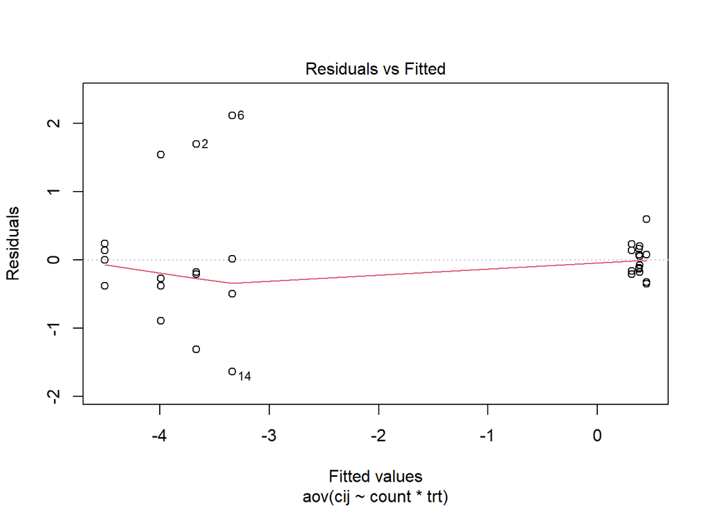

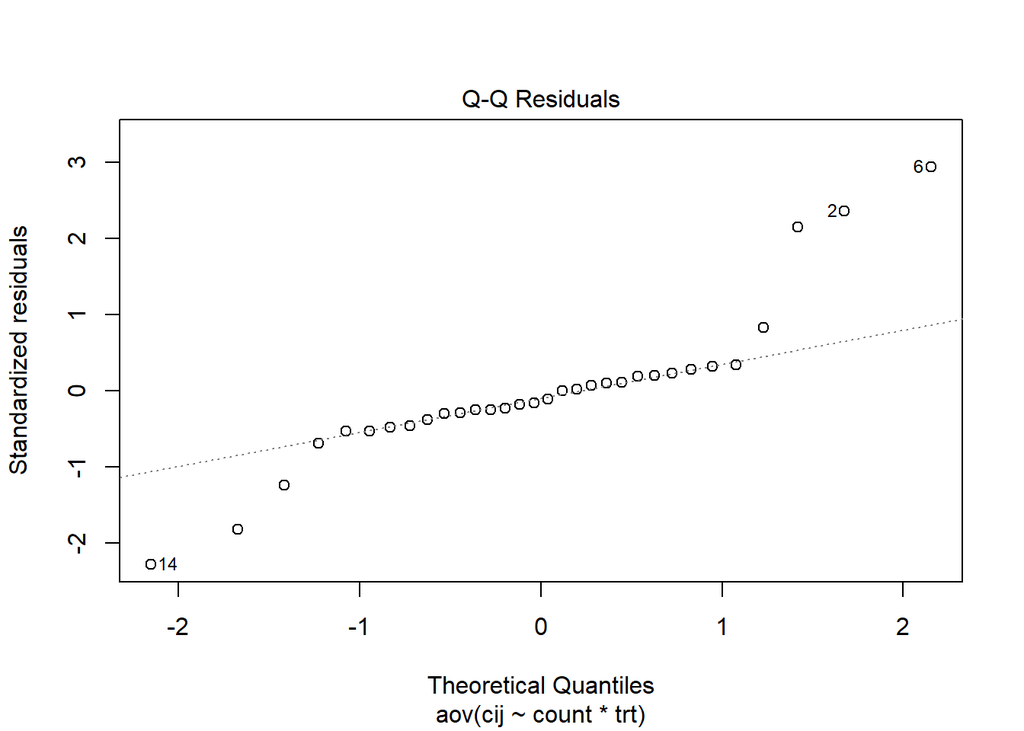

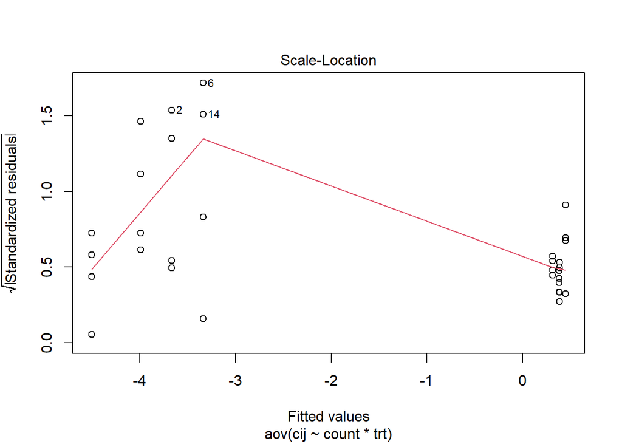

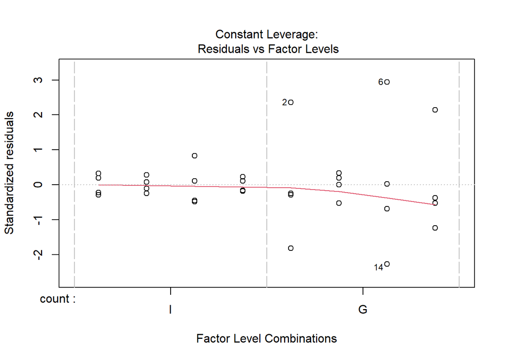

```r
fit <- aov(cij ~ count * trt, data = datamix[which(datamix$pair == "I:G"),])
plot(fit)
```

```r
summary(fit)
```

```
##             Df Sum Sq Mean Sq F value   Pr(>F)
## count        1 144.96  144.96 210.039 2.29e-13 ***
## trt          3   1.59    0.53   0.766    0.525
## count:trt    3   1.43    0.48   0.691    0.566
## Residuals   24  16.56    0.69
## ---
## Signif. codes:  0 '***' 0.001 '**' 0.01 '*' 0.05 '.' 0.1 ' ' 1
```

t-tests for Ci(j)s different from zero:

```r
dataT <- datamix[which(datamix$pair == "I:G" & datamix$trt != "H/H"),]
dataT <- droplevels(dataT)

# initialize a data frame to store the resulting p-value, mean, and 95% CI for each test
ttests <- data.frame(plate = levels(dataT$plate), strain = levels(dataT$strain)[1], pval = 1, tstat = 1, df = 1, stdev = 1, mean = 1, CIlower = 1, CIupper = 1)
ttests2 <- data.frame(plate = levels(dataT$plate), strain = levels(dataT$strain2)[1], pval = 1, tstat = 1, df = 1, stdev = 1, mean = 1, CIlower = 1, CIupper = 1)
ttests <- dplyr::bind_rows(ttests, ttests2)

# initialize a vector to store the p-values from each test so that they can be corrected for multiple testing
pvalues <- c()

# run the iterated tests
for (i in 1:nrow(ttests)) {
  n = 4 # the number of samples
  dataTest <- subset(dataT, plate == ttests$plate[i] & count == ttests$strain[i])
  res <- t.test(dataTest$cij, alternative = "two.sided", mu = 0)
  pvalues <- c(pvalues, res$p.value)
  ttests[i,4] <- res$statistic
  ttests[i,5] <- res$parameter
  ttests[i,6] <- res$stderr * n^2
  ttests[i,7] <- as.numeric(res$estimate[1])
  ttests[i,8] <- as.numeric(res$conf.int[1])
  ttests[i,9] <- as.numeric(res$conf.int[2])
}

# do the multiple testing correction
pCorr <- round(p.adjust(pvalues, method = "BH"), 4)

# enter the corrected p-values into the data frame
for (i in 1:nrow(ttests)) {
  ttests[i,3] <- pCorr[i]
}
ttests
```

```
##          plate strain   pval      tstat df     stdev       mean    CIlower
## 1 G high:I low      G 0.0287  -4.248565  3 12.567343 -3.3370732 -5.8367540
## 2 G low:I high      G 0.0004 -33.178861  3  2.172947 -4.5059951 -4.9382006
## 3  G low:I low      G 0.0147  -7.508606  3  8.505113 -3.9913464 -5.6830379
## 4 G high:I low      I 0.1360   2.025197  3  3.545923  0.4488246 -0.2564698
## 5 G low:I high      I 0.0279   4.662935  3  1.322779  0.3855021  0.1223975
## 6  G low:I low      I 0.0269   5.252175  3  1.159158  0.3805063  0.1499464
##      CIupper
## 1 -0.8373924
## 2 -4.0737895
## 3 -2.2996549
## 4  1.1541190
## 5  0.6486066
## 6  0.6110661
```

Dunnett tests for difference in other nutritional history treatments from H/H treatment (standard lab conditions):

```r
dataT <- datamix[which(datamix$pair == "I:G"),]
dataT <- droplevels(dataT)

c("I")
```

```
## [1] "I"
```

```r
DunnettTest(cij ~ trt, data = dataT[which(dataT$count == "I"),], control = "H/H")
```

```
##
##   Dunnett's test for comparing several treatments with a control :
##     95% family-wise confidence level
##
## $`H/H`
##               diff     lwr.ci    upr.ci   pval
## H/L-H/H 0.07387631 -0.4403775 0.5881301 0.9618
## L/H-H/H 0.13719882 -0.3770549 0.6514526 0.8166
## L/L-H/H 0.06888050 -0.4453733 0.5831343 0.9685
##
## ---
## Signif. codes:  0 '***' 0.001 '**' 0.01 '*' 0.05 '.' 0.1 ' ' 1
```

```r
c("G")
```

```
## [1] "G"
```

```r
DunnettTest(cij ~ trt, data = dataT[which(dataT$count == "G"),], control = "H/H")
```

```
##
##   Dunnett's test for comparing several treatments with a control :
##     95% family-wise confidence level
##
## $`H/H`
##               diff    lwr.ci   upr.ci   pval
## H/L-H/H -0.8397737 -3.008864 1.329317 0.6126
## L/H-H/H  0.3291482 -1.839942 2.498239 0.9556
## L/L-H/H -0.3251250 -2.494215 1.843965 0.9571
##
## ---
## Signif. codes:  0 '***' 0.001 '**' 0.01 '*' 0.05 '.' 0.1 ' ' 1
```

### Output figures

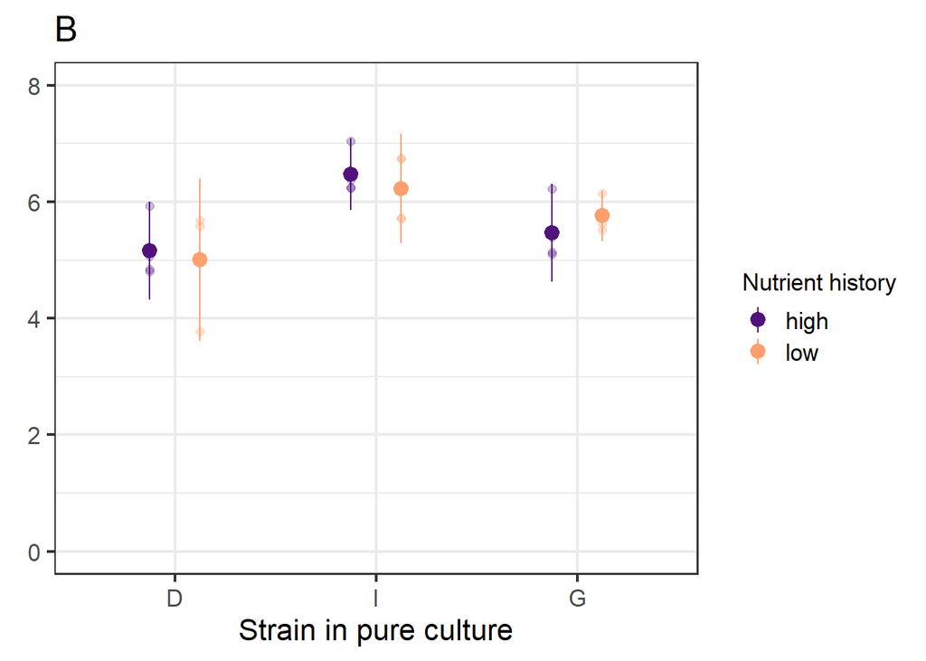

```r
# we alter the graph to fit into the combined figure
pPC2 <- ggplot(dataPC, aes(x = strain, y = logspores, color = nutrients)) +
  geom_point(size = 2, alpha = 0.3, show.legend = FALSE, position = position_dodge(width = 0.5)) +
  stat_summary(fun.data = "mean_cl_normal", size = 0.7, aes(y = logspores), position = position_dodge(width = 0.5)) +
  coord_cartesian(ylim = c(0,8)) +
  labs(y = element_blank(), x = "Strain in pure culture", title = "B", color = "Nutrient history") +
  customPlotTheme +
  scale_color_viridis_d(option = "magma", begin = 0.25, end = 0.8, direction = 1)
pPC2
```